# INDEX

Laetitia Onofre, Fabian Calla, Mirka Prieto

2022-11-06

El presente trabajo de investigación analiza los factores que pueden impactar en el Promedio Salarial de un país. Se sostiene que los factores económicos como: Inflación, Brecha de pobreza, Salario mínimo, Indice Costo de vida y sociales como: Tasa de Alfabetizacion, horas semanales,mujeres que trabajan son relevantes para esta investigación.

Llamamos la data (se llamará BDfinal)

```r
library(rio)
lkXLSX="https://github.com/FabianCalla/Avance-2-Trabajo-de-Investigaci-n/blob/main/BDfinal1.xlsx?raw=true"
BDfinal=import(lkXLSX)
```

*REGRESIÓN LINEAL**

**Laetitia**

```r
modelo1 = lm(PS~ICV+INF+MT, BDfinal)
summary(modelo1)
```

```
##
## Call:
## lm(formula = PS ~ ICV + INF + MT, data = BDfinal)
##
## Residuals:
##      Min       1Q   Median       3Q      Max
## -1809.04  -461.00   -27.06   436.30  1690.12
##
## Coefficients:
##             Estimate Std. Error t value Pr(>|t|)
## (Intercept)  639.949    284.359   2.250 0.027163 *
## ICV           20.662      2.137   9.669 4.29e-15 ***
## INF          -36.800      9.762  -3.770 0.000312 ***
## MT            -3.782      5.092  -0.743 0.459782
## ---
## Signif. codes:  0 '***' 0.001 '**' 0.01 '*' 0.05 '.' 0.1 ' ' 1
##
## Residual standard error: 672.4 on 80 degrees of freedom
## Multiple R-squared:  0.5611, Adjusted R-squared:  0.5446
## F-statistic: 34.09 on 3 and 80 DF,  p-value: 2.705e-14
```

**Mirka**

```r
modelo2 = lm(PS~Tasa_alfabetizacion+salario_min+brecha,BDfinal)
summary(modelo2)
```

```
##
## Call:
## lm(formula = PS ~ Tasa_alfabetizacion + salario_min + brecha,
##     data = BDfinal)
##
## Residuals:
##      Min       1Q   Median       3Q      Max
## -1274.94  -277.25   -50.16   195.91  2243.62
##
## Coefficients:
##                       Estimate Std. Error t value Pr(>|t|)
## (Intercept)         -752.29535  405.31015  -1.856   0.0671 .
## Tasa_alfabetizacion   19.35308    4.49295   4.307 4.65e-05 ***
## salario_min            1.08938    0.09005  12.098  < 2e-16 ***
## brecha                 5.99144    9.64438   0.621   0.5362
## ---
## Signif. codes:  0 '***' 0.001 '**' 0.01 '*' 0.05 '.' 0.1 ' ' 1
##
## Residual standard error: 517.7 on 80 degrees of freedom
## Multiple R-squared:  0.7398, Adjusted R-squared:  0.7301
## F-statistic: 75.82 on 3 and 80 DF,  p-value: < 2.2e-16
```

Segun el pvalor, este es un modelo valido. Se explica en el 73% y exhibe dos valores que influyen significativamente sobre la dependiente. El aumento en un punto de la tasa de alfabetización, incrementa en 19.35 dolares el promedio salarial. Asimismo, El aumento en un punto del salario mínimo, aumenta en un punto el promedio salarial.

**Fabián**

```r
modelo3= lm(PS~horassemana+negocole+explotacion, BDfinal)
summary(modelo3)
```

```
##
## Call:
## lm(formula = PS ~ horassemana + negocole + explotacion, data = BDfinal)
##
## Residuals:
##     Min      1Q  Median      3Q     Max
## -1697.1  -617.2  -162.9   412.4  2961.2
##
## Coefficients:
##             Estimate Std. Error t value Pr(>|t|)
## (Intercept) 2134.030   1261.249   1.692   0.0945 .
## horassemana  -12.065     34.069  -0.354   0.7242
## negocole      10.402      4.552   2.285   0.0249 *
## explotacion  -15.926      9.886  -1.611   0.1111
## ---
## Signif. codes:  0 '***' 0.001 '**' 0.01 '*' 0.05 '.' 0.1 ' ' 1
##
## Residual standard error: 919.1 on 80 degrees of freedom
## Multiple R-squared:  0.1799, Adjusted R-squared:  0.1491
## F-statistic: 5.848 on 3 and 80 DF,  p-value: 0.001156
```

- El p-valor nos indica que es un modelo válido
- Pero este se está explicando en un 15%
- La proporción de trabajadores ocupados más de 49 horas semanales (en contravensión a los lineamientos de la OIT) y el promedio de horas laborales efectivas en el país no explican la dependiente (salario), pero la proporción de empleados cubiertos por uno o más convenios colectivos sí. La relación indica que el aumento de un punto de esa proporción, estaría aumentando los salarios en 10.40 dólares.

**comparación de los 3 modelos**

```r
library(stargazer)
library(jtools)
stargazer(modelo1,modelo2,modelo3, type ="text")
```

```
##
## ==============================================================
##                                     Dependent variable:
##                               --------------------------------
##                                              PS
##                                  (1)        (2)        (3)
## --------------------------------------------------------------
## ICV                           20.662***
##                                (2.137)
##
## INF                           -36.800***
##                                (9.762)
##
## MT                              -3.782
##                                (5.092)
##
## Tasa_alfabetizacion                      19.353***
##                                           (4.493)
##
## salario_min                              1.089***
##                                           (0.090)
##
## brecha                                     5.991
##                                           (9.644)
##
## horassemana                                          -12.065
##                                                     (34.069)
##
## negocole                                            10.402**
##                                                      (4.552)
##
## explotacion                                          -15.926
##                                                      (9.886)
##
## Constant                      639.949**  -752.295* 2,134.030*
##                               (284.359)  (405.310) (1,261.249)
##
## --------------------------------------------------------------
## Observations                      84        84         84
## R2                              0.561      0.740      0.180
## Adjusted R2                     0.545      0.730      0.149
## Residual Std. Error (df = 80)  672.391    517.680    919.110
## F Statistic (df = 3; 80)      34.086***  75.825***  5.848***
## ==============================================================
## Note:                              *p<0.1; **p<0.05; ***p<0.01
```

En comparación, vemos que el modelo 2 está explicando mejor la dependiente con un 73% en el r2 ajustado.

Regresión con las 9 variables independientes:

```r
modelo4= lm(PS~horassemana+negocole+explotacion+Tasa_alfabetizacion+salario_min+brecha+ICV+INF+MT, BDfinal)
summary(modelo4)
```

```
##
## Call:
## lm(formula = PS ~ horassemana + negocole + explotacion + Tasa_alfabetizacion +
##     salario_min + brecha + ICV + INF + MT, data = BDfinal)
##
## Residuals:
##      Min       1Q   Median       3Q      Max
## -1102.86  -279.26   -60.26   245.70  1860.71
##
## Coefficients:
##                       Estimate Std. Error t value Pr(>|t|)
## (Intercept)         -3516.0649  1054.5512  -3.334  0.00134 **
## horassemana            60.4001    23.4787   2.573  0.01210 *
## negocole               -2.0972     2.6834  -0.782  0.43697
## explotacion            -1.4764     6.3991  -0.231  0.81817
## Tasa_alfabetizacion    21.0621     5.0238   4.192 7.56e-05 ***
## salario_min             1.1586     0.1755   6.603 5.34e-09 ***
## brecha                 13.3433    10.7846   1.237  0.21990
## ICV                     1.7484     3.4296   0.510  0.61171
## INF                    -9.0102     8.4043  -1.072  0.28716
## MT                      3.9479     4.7903   0.824  0.41250
## ---
## Signif. codes:  0 '***' 0.001 '**' 0.01 '*' 0.05 '.' 0.1 ' ' 1
##
## Residual standard error: 501.7 on 74 degrees of freedom
## Multiple R-squared:  0.774,  Adjusted R-squared:  0.7465
## F-statistic: 28.16 on 9 and 74 DF,  p-value: < 2.2e-16
```

- El p-valor nos indica que es un modelo válido
- Este se está explicando en un 75% mejor que todos los modelos anteriores
- Existen 3 variables que influyen en la dependiente:

En primer lugar, el aumento en un punto respecto al promedio de las horas semanales estaría aumentando en 60.40 el promedio salarial, sin embargo, es la que menos explica la dependiente.

**ANÁLISIS FACTORIAL EXPLORATORIO**

1. Subsetear la data

```r
dontselect=c("Pais", "PS")
select=setdiff(names(BDfinal), dontselect)
DL=BDfinal[,select]
```

2.Calculo matriz de correlación

```r
library(polycor)
corL=polycor::hetcor(DL)$correlations
```

3.Explorar correlaciones

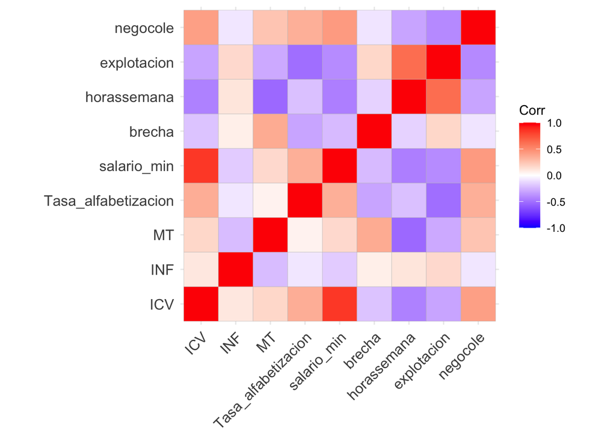

```r
library(ggcorrplot)
ggcorrplot(corL)
```

4.Ver si datos dejan factorizar

```r
library(psych)
psych::KMO(corL)
```

```
## Kaiser-Meyer-Olkin factor adequacy
## Call: psych::KMO(r = corL)
## Overall MSA =  0.63
## MSA for each item =
##                 ICV                 INF                  MT Tasa_alfabetizacion
##                0.56                0.21                0.64                0.72
##         salario_min              brecha         horassemana         explotacion
##                0.61                0.58                0.69                0.64
##            negocole
##                0.89
```

El overall es 0.63 por lo cual, todavía estamos dentro del valor adecuado para un análisis factorial.

5.Ver si la matriz de correlaciones es adecuada *Hnula: Matriz identidad

```r
cortest.bartlett(corL,n=nrow(DL))$p.value>0.05
```

```
## [1] FALSE
```

- Hnula: Matriz singular (debe salir falsa)

```r
library(matrixcalc)

is.singular.matrix(corL)
```

```
## [1] FALSE
```

Vemos que ambos resultado son False y podemos continuar

6. Aquí vemos en cuántos factores se puede redimensionar la data

```r
fa.parallel(DL, fa = 'fa',correct = T,plot = F)
```

```
## Parallel analysis suggests that the number of factors =  3  and the number of components =  NA
```

Entonces, vemos que en este caso se sugiere 3 como número de factor (de 9, se pueden represtnar en 3).

7. Ahora redimensionamos a un menor numero de factores:

```r
library(GPArotation)
resL <- fa(DL,
            nfactors = 3,
            cor = 'mixed',
            rotate = "varimax",
            fm="minres")
print(resL$loadings)
```

```
##
## Loadings:
##                     MR1    MR3    MR2
## ICV                  1.008
## INF                         0.243
## MT                   0.163 -0.346  0.651
## Tasa_alfabetizacion  0.309 -0.481 -0.287
## salario_min          0.815 -0.225
## brecha              -0.180  0.141  0.665
## horassemana         -0.426  0.525 -0.443
## explotacion         -0.282  0.851
## negocole             0.402 -0.361
##
##                  MR1   MR3   MR2
## SS loadings    2.257 1.611 1.152
## Proportion Var 0.251 0.179 0.128
## Cumulative Var 0.251 0.430 0.558
```

```r
print(resL$loadings,cutoff = 0.5)
```

```
##
## Loadings:
##                     MR1    MR3    MR2
## ICV                  1.008
## INF
## MT                                 0.651
## Tasa_alfabetizacion
## salario_min          0.815
## brecha                             0.665
## horassemana                 0.525
## explotacion                 0.851
## negocole
##
##                  MR1   MR3   MR2
## SS loadings    2.257 1.611 1.152
## Proportion Var 0.251 0.179 0.128
## Cumulative Var 0.251 0.430 0.558
```

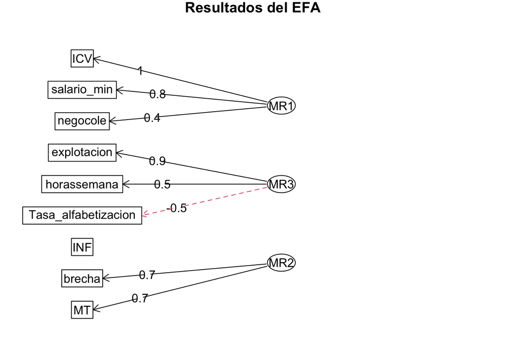

```r
fa.diagram(resL,main = "Resultados del EFA")
```

```r
print(resL$loadings,cutoff = 0.5)
```

```
##
## Loadings:
##                     MR1    MR3    MR2
## ICV                  1.008
## INF
## MT                                 0.651
## Tasa_alfabetizacion
## salario_min          0.815
## brecha                             0.665
## horassemana                 0.525
## explotacion                 0.851
## negocole
##
##                  MR1   MR3   MR2
## SS loadings    2.257 1.611 1.152
## Proportion Var 0.251 0.179 0.128
## Cumulative Var 0.251 0.430 0.558
```

La varianza acumulada de 0.56; esto significa que hemos recuperado el 56 de información.

8. Evaluamos qué variables aportaron más a los factores

```r
sort(resL$communality)
```

```
##                 INF            negocole Tasa_alfabetizacion              brecha
##          0.06260397          0.29241332          0.40880686          0.49474554
##                  MT         horassemana         salario_min         explotacion
##          0.57069168          0.65274600          0.71749333          0.80327553
##                 ICV
##          1.01680493
```

**En este caso, vemos que el que más aporta es ICV** el que menos aporta el Indice de Inflación.

- ¿Qué variables contribuyen a más de un factor?

Complejidad:

```r
sort(resL$complexity)
```

```
##                 ICV                 INF         salario_min         explotacion
##            1.002365            1.112595            1.160793            1.217780
##              brecha                  MT            negocole Tasa_alfabetizacion
##            1.240381            1.669666            1.983776            2.412732
##         horassemana
##            2.894384
```

En este caso, nos quedamos con la que se encuentre más cercano al 1: ICV.

9. Valores proyectados (resumen)

```r
library(magrittr)
as.data.frame(resL$scores)%>%head()
```

```
##          MR1        MR3        MR2
## 1 -0.9743401 -0.4626258 -0.3025519
## 2  1.2258096 -0.8451106  0.1313751
## 3 -0.6902954  0.5383249 -1.2153587
## 4  2.4826314  1.1996279  0.1215207
## 5 -0.6713157 -0.4018913 -0.4647594
## 6  2.1284316 -0.2055567  0.4063245
```